# 606 HW3

Rajwant Mishra

February 25, 2019

Graded: 3.2 (see normalPlot), 3.4, 3.18 (use qqnormsim from lab 3), 3.22, 3.38, 3.42

3.2 Area under the curve What percent of a standard normal distribution N(??=0,??=1) is found in each region? Be sure to draw a graph.

1. Z > - 1.13
   $$Z = x − μ σ$$

```r
#-------------------SMAPLE START


mu <- 0
sd <- 1
Z <- -1.13

# From the formula value for 'x'
x <- Z * sd + mu

# Finding probability for x > -1.13
# 1 - pnorm(x, mean = 0, sd = 1)

# Finding probability fo x > -1.13
# 1 - pnorm(x, mean = 0, sd = 1)
shade <- 1- pnorm(x, mean = 0, sd = 1)

pnorm(shade, mean = 0, sd = 1)
```

```
## [1] 0.8080579
```

```r
qnorm(shade,0,1)
```

```
## [1] 1.13
```

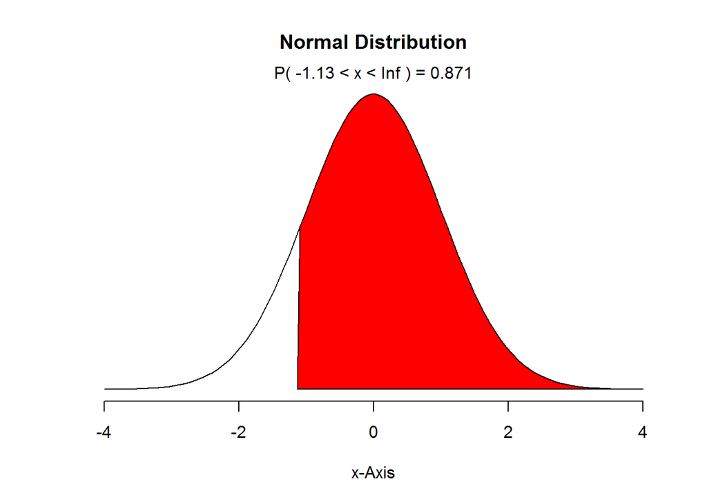

```r
shade <- 1- pnorm(x, mean = 0, sd = 1)

normalPlot(mean = 0, sd = 1, bounds = c(x,qnorm(1)), tails = FALSE)
```

#### Answer

The percentage represented on the region is: 87.08%

2. Z < 0.18

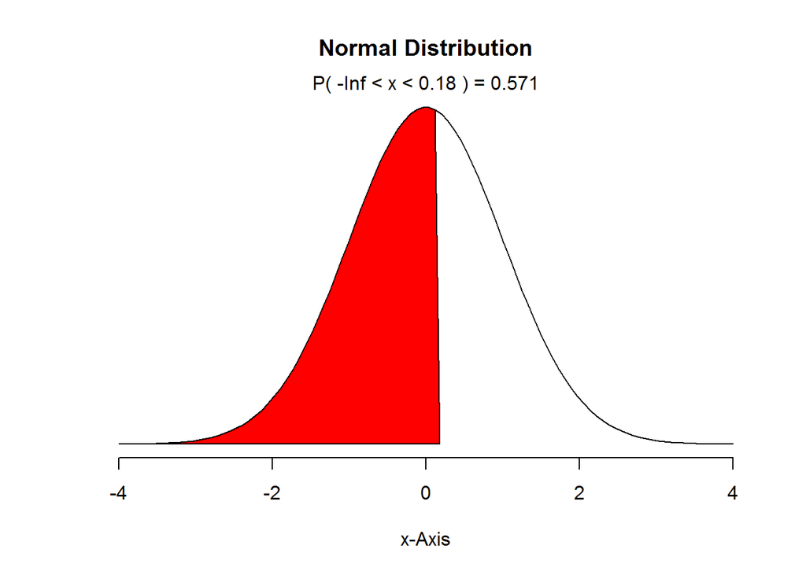

```r
z <- 0.18
# From the formula value for 'x'
x <- z * sd + mu

# Finding probability fo x < 0.18
shade<-probx<-pnorm(x, mean = 0, sd = 1)

normalPlot(mean = 0, sd = 1, bounds = c(-qnorm(1),x), tails = FALSE)
```

#### Answer

The percentage represented on the region is: 57.14%

3. Z > 8

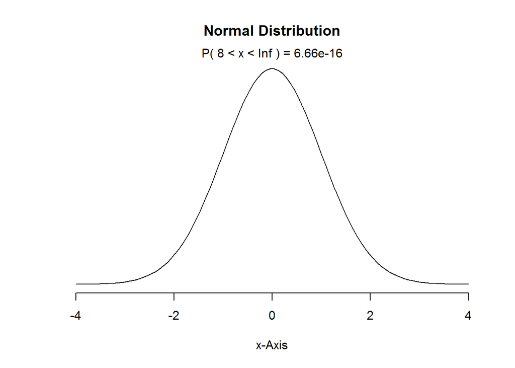

```r
mu <- 0
sd <- 1
z <- 8
# Value for  'x' given Z score
x <- z * sd + mu


# Since we have that x>8 , we need to get 1-p(8)
shade <- 1 - pnorm(x, mean = 0, sd = 1)


normalPlot(mean = 0, sd = 1, bounds = c(x, qnorm(1)), tails = FALSE)
```

#### Answer

The percentage represented on the region is: ~ 0.00%

4. |Z| < 0.5

```r
mu <- 0
sd <- 1
Z <- 0.5
# finding value for 'x'
x <- Z * sd + mu
x
```

```
## [1] 0.5
```

```r
# Since we have that |x|<0.5

x1 <- pnorm(-x, mean = 0, sd = 1)
x2 <- pnorm(x, mean = 0, sd = 1)
x2 - x1
```

```
## [1] 0.3829249
```

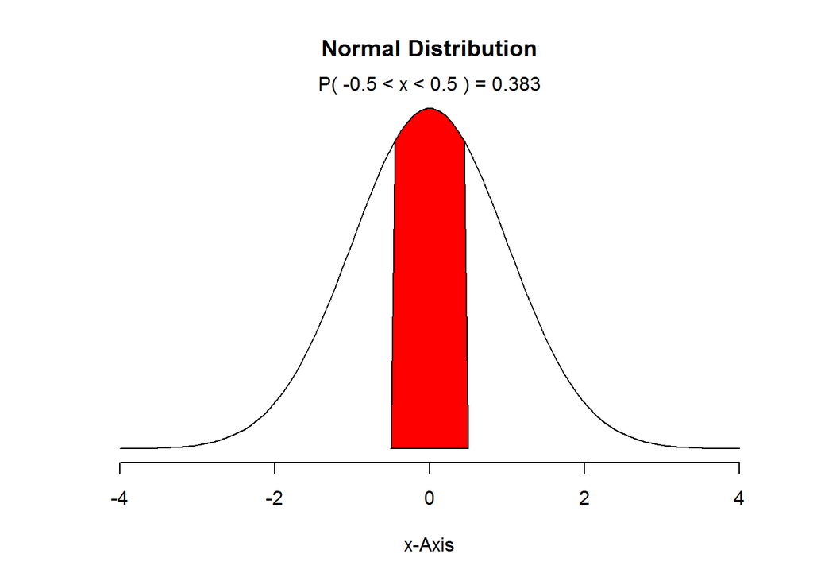

```r
normalPlot(mean = 0, sd = 1, bounds = c(-x, x), tails = FALSE)
```

#### Answer

The percentage represented on the region is: 38.29%

## 3.4

3.4 Triathlon times, Part I. In triathlons, it is common for racers to be placed into age and gender groups. Friends Leo and Mary both completed the Hermosa Beach Triathlon, where Leo competed in the Men, Ages 30 - 34 group while Mary competed in the Women, Ages 25 - 29 group. Leo completed the race in 1:22:28 (4948 seconds), while Mary completed the race in 1:31:53 (5513 seconds). Obviously Leo finished faster, but they are curious about how they did within their respective groups. Can you help them? Here is some information on the performance of their groups: . The finishing times of the Men, Ages 30 - 34 group has a mean of 4313 seconds with a standard deviation of 583 seconds. . The finishing times of the Women, Ages 25 - 29 group has a mean of 5261 seconds with a standard deviation of 807 seconds. . The distributions of finishing times for both groups are approximately Normal. Remember: a better performance corresponds to a faster finish. (a) Write down the short-hand for these two normal distributions. #### Answer > Group Men, Ages 30 - 34: N(µ =4313, sd =583), Group Women, Ages 25-29: N(µ =5261, sd =807).

2. What are the Z-scores for Leo’s and Mary’s finishing times? What do these Z-scores tell you?

```r
leo <-4948

mu <- 4313
sd<- 583

Z = (leo - mu )/sd

pnorm(Z)
```

```
## [1] 0.8619658
```

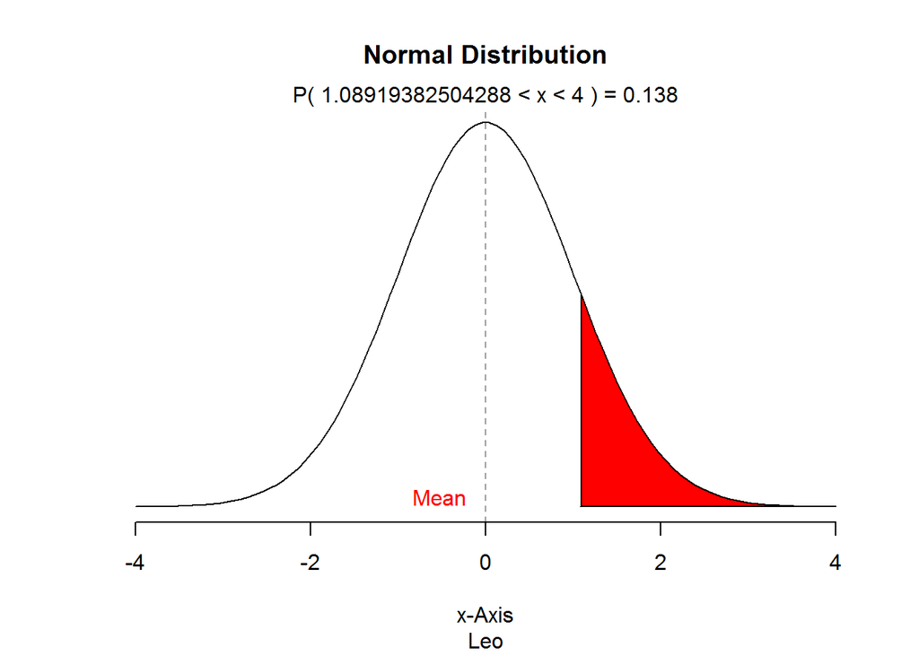

```r
rajplot(mean = 0, sd = 1, bounds = c(Z, 4), tails = FALSE,"Leo")
```

```r
mer <-5513
mu2 <- 5261
sd2<- 807

Z2 = (mer - mu2 )/sd2

pnorm(Z2)
```

```
## [1] 0.6225814
```

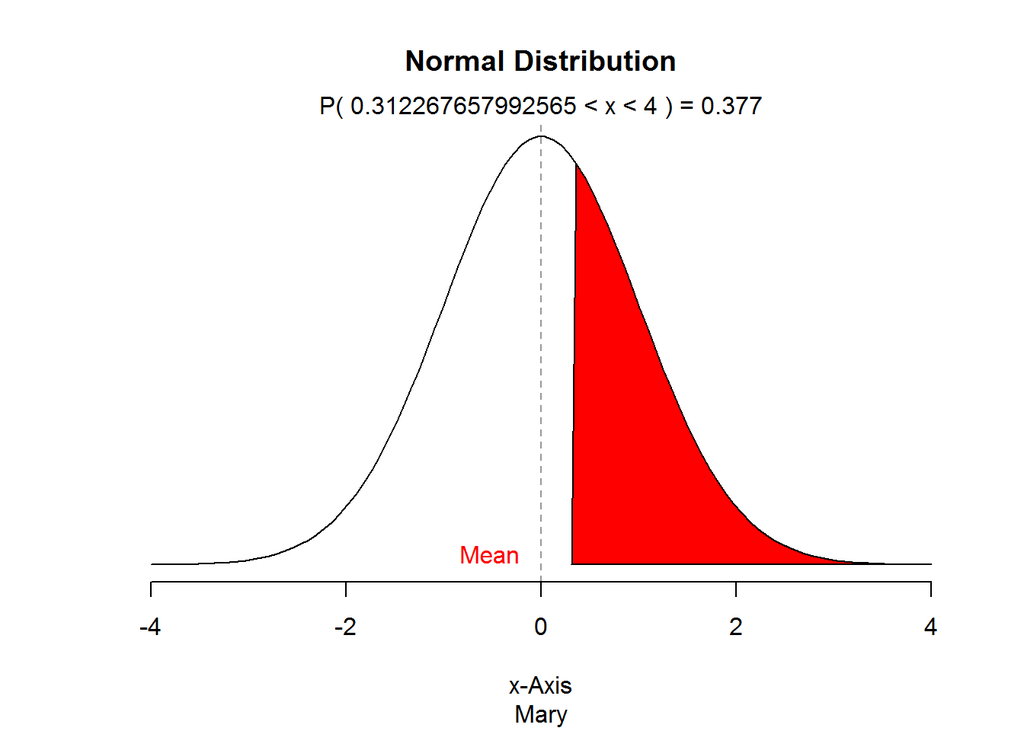

```r
rajplot(mean = 0, sd = 1, bounds = c(Z2, 4), tails = FALSE,"Mary")
```

#### Answer

Z-score is the number of standard deviations from the mean.

3. Did Leo or Mary rank better in their respective groups? Explain your reasoning.

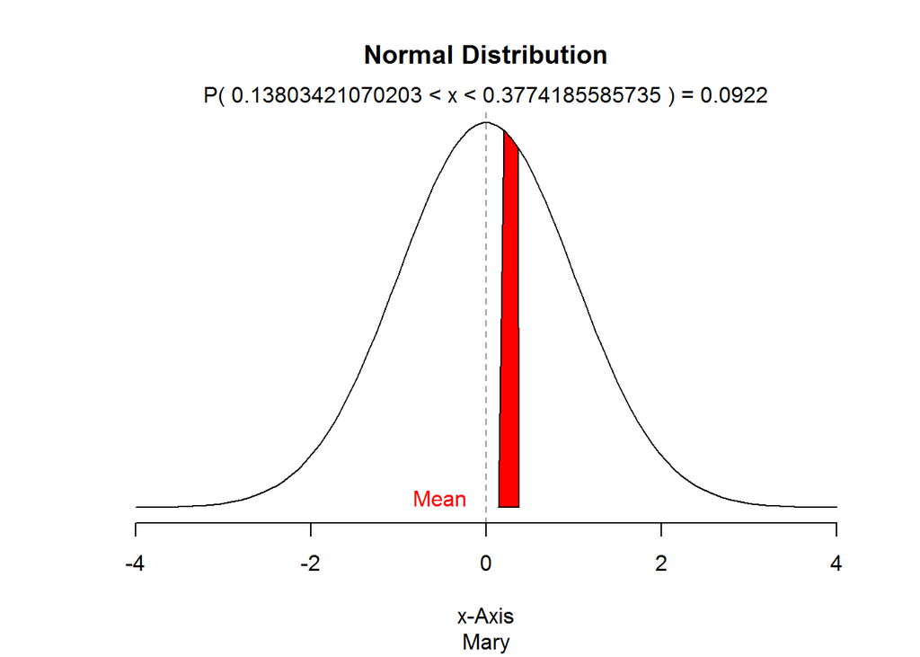

```r
leoRank <- 1-pnorm(Z)
MaryRank <- 1-pnorm(Z2)

rajplot(mean = 0, sd = 1, bounds = c(leoRank, MaryRank ), tails = FALSE,"Mary")
```

```r
pnorm(Z)
```

```
## [1] 0.8619658
```

```r
pnorm(Z,lower.tail=FALSE)
```

```
## [1] 0.1380342
```

#### Answer

5. What percent of the triathletes did Mary finish faster than in her group?

```r
pnorm(Z2)
```

```
## [1] 0.6225814
```

```r
pnorm(Z2,lower.tail=FALSE)
```

```
## [1] 0.3774186
```

#### Answer

6. If the distributions of finishing times are not nearly normal, would your answers to parts (b) - (e) change? Explain your reasoning.

#Answer Z-scores of not normal distributions are relevant only for analysis in a respective group.We will not be able to compare two people from different groups based on Z-scores of not normal distributions.since we cannot use the normal probability table to calculate probabilities and percentiles without a normal model, it would impact the calculation. The answer to part (b) would not change as Z-scores can be calculated for distributions that are not normal. Answer to (C) might change depending on varaince in data points. (e)Each of these answers would need to be reevaluated and recalculated based upon a non-normal or a normalized distribution.

3.18 Heights of female college students. Below are heights of 25 female college students. 1 54, 2 55, 3 56, 4 56, 5 57, 6 58, 7 58, 8 59, 9 60, 10 60, 11 60, 12 61, 13 61, 14 62, 15 62, 16 63, 17 63, 18 63, 19 64, 20 65, 21 65, 22 67, 23 67, 24 69, 25 73 (a) The mean height is 61.52 inches with a standard deviation of 4.58 inches. Use this information to determine if the heights approximately follow the 68-95-99.7% Rule. (b) Do these data appear to follow a normal distribution? Explain your reasoning using the graphs provided below.

```r
url <- "https://raw.githubusercontent.com/jbryer/DATA606Fall2016/master/Data/Data%20from%20openintro.org/Ch%203%20Exercise%20Data/fheights.txt"
hdata <- read.table(url, header = TRUE, stringsAsFactors = FALSE)
head(hdata)
```

```
##   heighs
## 1     54
## 2     55
## 3     56
## 4     56
## 5     57
## 6     58
```

```r
h<- 54:73
hgiven <- 61.52
mu <- 61.52
sd<- 4.58

hdata$Z = (hdata$heighs-mu)/sd
hdata$sd <- round(hdata$Z,0)

quantile(hdata$heighs, c(.67, .95, .997))
```

```
##    67%    95%  99.7%
## 63.000 68.700 72.724
```

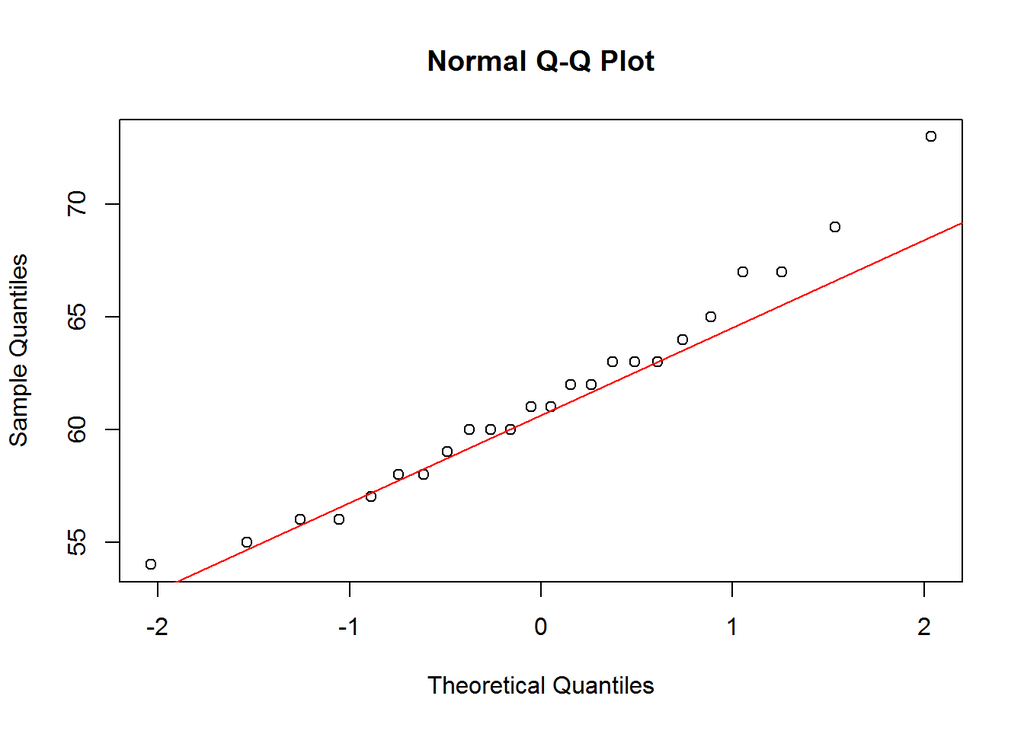

```r
#    67%    95%  99.7%
# 63.000 68.700 72.724
# For this data point lets find  Zscore

zscore67 <- (63-mu)/sd
zscore95 <- (68-mu)/sd # in 95th percentile of data
zscore99 <- (72.724-mu)/sd # in 95th percentile of data

# Comapring Probability
prob67 <- pnorm(63,mu,sd)
prob95 <- pnorm(68,mu,sd) # in 95th percentile of data
prob99 <- pnorm(72.724,mu,sd )# in 95th percentile of data

scoreData<- data.frame(X=c(63, 68.700, 72.724 ), Zcore= c(zscore67,zscore95,zscore99), probability= c(prob67,prob95,prob99))

# From the check its clear that all the Quantiles value of this diributions are follwoing  68-95-99.7% Rule.
# - All the datapoints are having probability of less than the 67,95 an 99 and they are in 1 standard devialtion from MEAN.





qqnorm(hdata$heighs)
qqline(hdata$heighs, col = 2)
```

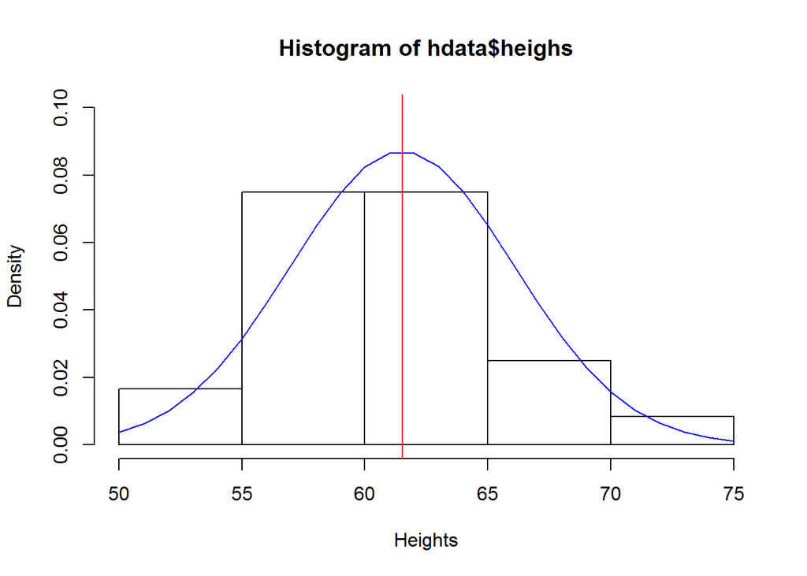

```r
hist(hdata$heighs, probability = TRUE, xlab = "Heights", ylim = c(0, 0.1))
x <- 50:75
y <- dnorm(x = x, mean = mu, sd = sd)
lines(x = x, y = y, col = "blue")
abline(v = mu, col = "red")
```

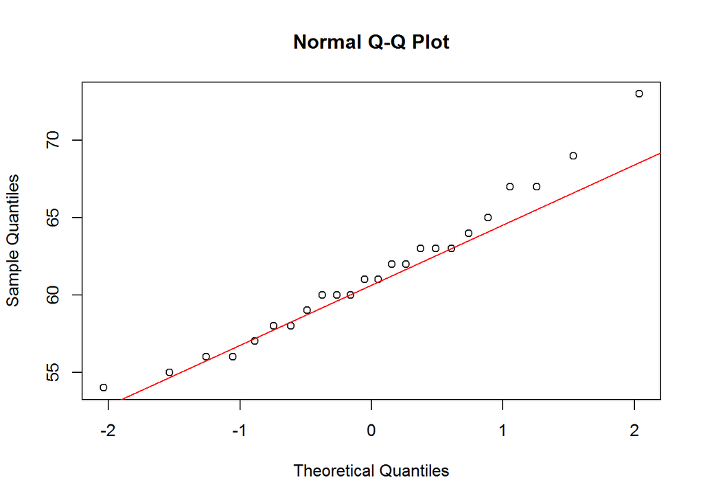

```r
qqnorm(hdata$heighs)
qqline(hdata$heighs, col = 2)
```

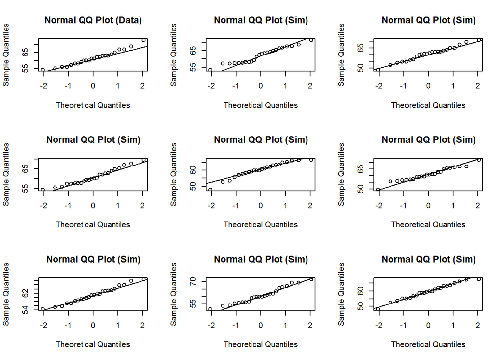

```r
qqnormsim(hdata$heighs)
```

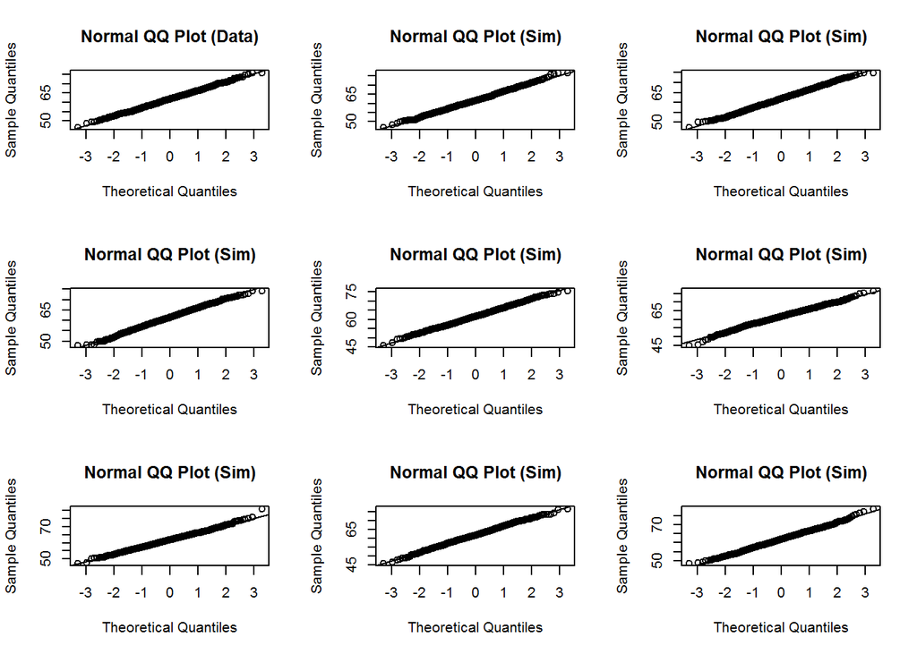

```r
#1000 Random sample

height1k <- rnorm(n = 1000,mu,sd)

qqnormsim(height1k)
```

```r
# height1k <- rnorm(n = 10000000,mu,sd)
#
# qqnormsim(height1k)
```

#### Answer

The distribution is unimodal and symmetric. The superimposed normal curve seems to indicate normal distribution. Since the sample size is less it would be very tough to see exact distribution but it would tends towrd very normal ditribution as sample size increases.

If you see simulation of 1000 records , its very much a normal distribution. As most of the data points fall in |1|,|2|,|3| std deviation .

3.22 Defective rate. A machine that produces a special type of transistor (a component of computers) has a 2% defective rate. The production is considered a random process where each transistor is independent of the others. (a) What is the probability that the 10th transistor produced is the first with a defect?

```r
#  1 2 3 4 5 6 7 8 9 Defect ......
# Here DEFECT is considered as Success
#It's a case of geometric distribution. In this case, 9 is the number of failures until we find a defective part(Success).
# Probaility of 1 in defect in 10 is 2% i.e. pd^1*(i-pd)10-1

ps<- (1 - 0.02)^9 * 0.02
ps
```

```
## [1] 0.01667496
```

```r
# We can also use dgeom(n,p), here
# n= vector of quantiles representing the number of failures in a sequence of Bernoulli trials before success occurs.
# p= vector of probabilities
# Here 9 is number of failure before success
dgeom(9,0.02)
```

```
## [1] 0.01667496
```

#### Answer

2. What is the probability that the machine produces no defective transistors in a batch of 100?

```r
#Probability of defet is 0.02
# so noDefct probability = (1-0.02)

# noDefect for 100 units will be :
pf100 <- (1-0.02)^100
pf100
```

```
## [1] 0.1326196
```

```r
# Since there is no Success in the event of 100 so we didn't multiply (0.2)^0 = 1
#This is conventionally interpreted as the number of 'successes' in size trials.
dbinom(0, 100, .02)
```

```
## [1] 0.1326196
```

#### Answer

The probability that the machine produces no defective transistors in a batch of 100 is 13.26%.

3. On average, how many transistors would you expect to be produced before the first with a defect? What is the standard deviation?

```r
ps = 0.02
mu = 1/ps
sd= (1-ps)/(ps)^2
sd = sqrt(sd)

p_mu_sd <- data.frame(ps,mu,sd)
```

#### Answer:

On average, I would expect to produce 50 transistors before the first one comes with a defect, with a standard deviation of 49.50.

4. Another machine that also produces transistors has a 5% defective rate where each transistor is produced independent of the others. On average how many transistors would you expect to be produced with this machine before the first with a defect? What is the standard deviation?

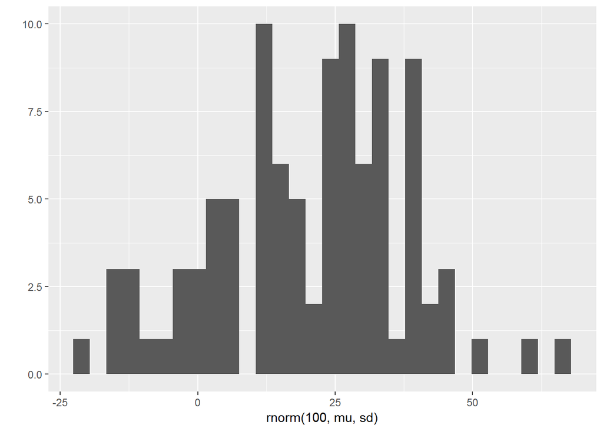

```r
ps = 0.05
mu = 1/ps
sd= (1-ps)/(ps)^2
sd = sqrt(sd)

p_mu_sd <- rbind(p_mu_sd ,c(ps,mu,sd))
qplot(x = rnorm(100,mu,sd))
```

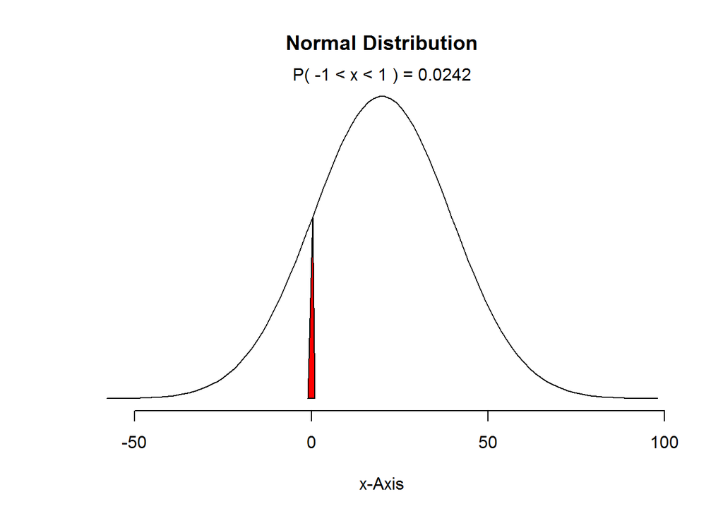

```r
normalPlot(mu,sd)
```

#### Answer:

On average, I would expect to produce 20 transistors before the first one comes with a defect, with a standard deviation of ~19.50. *** (e) Based on your answers to parts (c) and (d), how does increasing the probability of an event a???ect the mean and standard deviation of the wait time until success?

```r
p_mu_sd
```

```
##     ps mu       sd
## 1 0.02 50 49.49747
## 2 0.05 20 19.49359
```

#### Answer:

Increasing Probability of an Event , decreases the Mean and Std. Deviation . We can see the info clearly from abvoe table.

3.38 Male children. While it is often assumed that the probabilities of having a boy or a girl are the same, the actual probability of having a boy is slightly higher at 0.51. Suppose a couple plans to have 3 kids. (a) Use the binomial model to calculate the probability that two of them will be boys.

```r
pb <- 0.51 # Probability of Boys
totalKid <- 3 # Total kid
kb = 2 #Boy expected = 2

nk <- factorial(totalKid) / (factorial(2)*factorial(totalKid - 2))

# Probability of 2 success with failuire  probility of (1-0.51)
probboy <- dgeom(2,(1-0.51))   # 0.127449
# Using formula
# probboy <-(pb^2)*((1-pb)^(totalKid-2))

tpb <- nk*probboy
tpb
```

```
## [1] 0.382347
```

```r
#factorial(totalKid)/(factorial(kb)*(factorial(totalKid-kb)))*(pb^kb)*((1-pb)^(totalKid-kb))

# Other way  k =2 n = 3  3c2 *(pb^2)*((1-pb)^(totalKid-2))
```

#### Answer:

The probability that two of them will be boys is 38.23%

2. Write out all possible orderings of 3 children, 2 of whom are boys. Use these scenarios to calculate the same probability from part (a) but using the addition rule for disjoint outcomes. Confirm that your answers from parts (a) and (b) match.

```r
# All Possible 3 children: BBB,BBG,BGB,GBB,BGG,GGB,GBG,GGG
# 3 orderings include 2 boys.
factorial(3)
```

```
## [1] 6
```

```r
children <- data.frame(c("BBG", "BGB", "GBB"))
#probability of getting two boys and a girl
# this part is exactly the same as (p^num_boys)*((1-p)^(num_kids-num_boys))
#multiply probability of getting two boys and a girl by 3 cases
# 3 is exactly the same as factorial(num_kids) / (factorial(num_boys)*factorial(num_kids - num_boys))
children$p <- c(pb * pb * (1 - pb), pb * (1 - pb) * pb, (1 - pb) *
    pb * pb)
names(children) <- c("Combination", "probability")

# total probability of 2 boy and 1 girl is
sum(children$probability)
```

```
## [1] 0.382347
```

```r
identical(tpb ,sum(children$probability))
```

```
## [1] TRUE
```

#### Answer:

total probability of 2 boy and 1 girl is 0.382347.

> Disjoint events cannot happen at the same time. In other words, they are mutually exclusive. Put in formal terms, *events A and B are disjoint if their intersection is zero*: … Disjoint events are disjointed, or not connected. Another way of looking at disjoint events are that they have no outcomes in common. here `tpb - sum(children$probability)) = 0` both a and b match.
3. If we wanted to calculate the probability that a couple who plans to have 8 kids will have 3 boys, briefly describe why the approach from part (b) would be more tedious than the approach from part (a).

#### Answer:

It would be more tedious because it will be harder to list and count all cases with 3 boys and 5 girls than cases with 2 boys and a girl. ‘choose(8,3)’

3.42 Serving in volleyball. A not-so-skilled volleyball player has a 15% chance of making the serve, which involves hitting the ball so it passes over the net on a trajectory such that it will land in the opposing team’s court. Suppose that her serves are independent of each other. (a) What is the probability that on the 10th try she will make her 3rd successful serve?

```r
## This is a Negative Binomial distribution , since last trial must be a success

p <- 0.15
n <- 10
k <- 3

#number of cases with 2 successes and 7 failures in 9 first attemps

num_cases <- factorial(n-1)/(factorial(k-1)*(factorial(n-k)))
prob <-num_cases*(p^k)*((1-p)^(n-k))

prob
```

```
## [1] 0.03895012
```

```r
# Alternate method

choose(n - 1, k - 1) * (1 - p)^(n - k) * p^k
```

```
## [1] 0.03895012
```

#### Answer:

2. Suppose she has made two successful serves in nine attempts. What is the probability that her 10th serve will be successful?

#### Answer:

Since events are indipendent, success for serve is 15% .

3. Even though parts (a) and (b) discuss the same scenario, the probabilities you calculated should be di???erent. Can you explain the reason for this discrepancy?

#### Answer:

The first time we used the negative binomial distribution formula, which describes the probability of observing the kth success on the nth trial. In Part (b) calculates the probability that last serve is success i.e. 15% or .15 as given in problem. Question (a) = part(b)* probability of 2 success in 9th attempt.( That two of the previous nine attempts are successes.)

Quick Check :

```r
p <- 0.15
n <- 10
k <- 3
parta <- choose(n - 1, k - 1) * (1 - p)^(n - k) * p^k

#number of cases with 2 successes and 7 failures
p <- 0.15
n <- 9
k <- 2

partb2in9<- choose(n,k) * (1 - p)^(n - k) * p^k

# partb2in9* Probability os ucces of last serve

partc<-  partb2in9 *  p
parta
```

```
## [1] 0.03895012
```

```r
partc
```

```
## [1] 0.03895012
```